# Lista nº 1 – Geração de Números Aleatórios

EST066 2022.1 - Estatística Computacional 2

Pedro Henrique Corrêa de Almeida UFJF Matrícula : 202065075AD

01/06/2022

# Definindo semente aleatória

Uma vez que vamos realizar geração de números aleatórios, vamos definir uma semente a fim de garantir replicabilidade dos resultados obtidos.

```r
set.seed(741896)
```

# Questão 1

```r
202065075 %% 3
```

```
## [1] 0
```

Como mat (mod 3) é igual a 0, vamos obter a quantilica da distribuição $Weibull$ a fim de construir um gerador de números aleatórios da mesma, para isso vamos considerar a $F(x)$ da $Weibull$ como:

$$F(x) = 1 - e^{(x/\lambda)^k}$$

Onde $\lambda$ é o parâmetro de escala., e $k$ o parâmetro de forma

Uma vez que a função quantilíca é a inversa da função de distribuição $F(x)$, temos a seguinte relação, onde $p$ é a $P(X <= x)$:

$$F(F^{-1}(p)) = p$$

Dessa forma, aplicando $F^{-1}(p)$ em $F(x)$, temos:

$$1 - e^{-(F^{-1}(p)/\lambda)^k} = p$$
Manipulando a equação temos:

$$e^{-(F^{-1}(p)/\lambda)^k} = 1 - p$$
Aplicando $log$ em ambos os lados da igualdade, temos:

$$log(e^{-(F^{-1}(p)/\lambda)^k}) = log(1 - p)$$
Uma vez que, $log(e^{x}) = x$, temos:

$$-(F^{-1}(p)/\lambda)^k = log(1 - p)$$

Com isso, concluímos:

$$F^{-1}(p) = \lambda((-log(1 - p))^{1/k})$$
Uma vez que sabemos a função explícita da quantílica da distribuição $Weibull$ vamos implementar essa função.

```r
 # Definindo a função quantilíca obtida
quantilica_weibull <- function(p, forma = 1, escala = 1){
  escala*((-log(1-p))**(1/forma))
}
```

Agora vamos definir um gerador da distribuição $Weibull$ a partir da função quantílica.

```r
 # Definindo o gerador da weibull
gerador_weibull <- function(forma, escala, N = 1E4){
  U <- runif(N)
  quantilica_weibull(U, forma = forma, escala = escala)
}
```

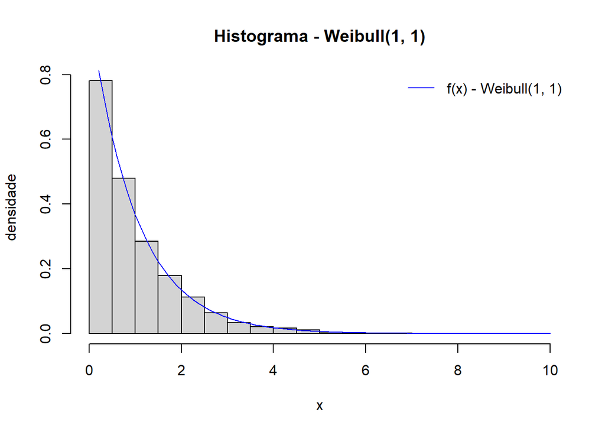

```r
 # Gerando uma Weibull(1,1)
x_weibull <- gerador_weibull(1, 1)
 # Plotando o histograma
hist(x_weibull, freq = F, main = "Histograma - Weibull(1, 1)", xlab = "x", ylab = "densidade")
 # Plotando a curva da densidade
curve(dweibull(x, 1, 1), add = T, col = "blue")
 # Plotando a legenda
legend("topright", legend = "f(x) - Weibull(1, 1)", bty = "n", col = "blue", lty = 1)
```

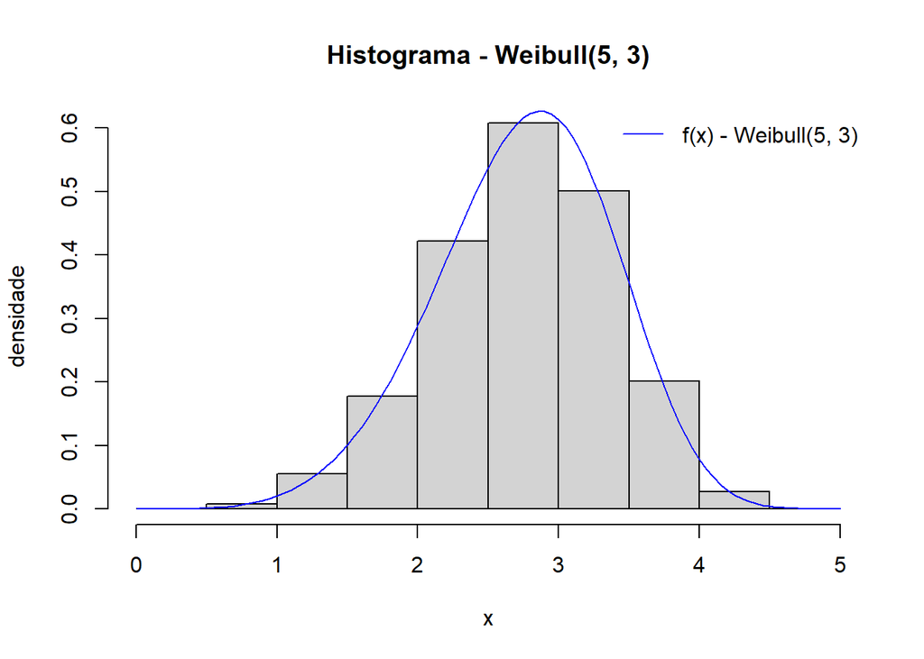

```r
 # Gerando uma Weibull(5,3)
x_weibull_2 <- gerador_weibull(5,3)

hist(x_weibull_2, freq = F, main = "Histograma - Weibull(5, 3)", xlab = "x", ylab = "densidade")
curve(dweibull(x, 5, 3), add = T, col = "blue")
 # Plotando a legenda
legend("topright", legend = "f(x) - Weibull(5, 3)", bty = "n", col = "blue", lty = 1)
```

# Questão 2

A fim de gerar números aleatórios dessa variável aleatória, vamos utilizar o método da inversa. Para isso vamos considerar:

$$F_X(F_X^{-1}(p)) = p$$
Loo:

$$F_X(F_X^{-1}(p)) - p = 0$$

Ou seja, queremos o valor de x em $F_X(x)$ que menos o valor de p dê igual a zero. Porém a fim de realizar esse cálculo numericamente vamos considerar:

$$(F_X(F_X^{-1}(p)) - p)^2 = 0$$

Dessa forma, vamos utilizar a função `optimize` a fim de encontrar a raiz dessa equação. Além disso, vamos considerar que $0 <= x <= 1$. E, a fim de criar uma função vetorizada vamos utilizar a função `lapply`, e, posteriormente `unlist` para retornar tudo em um vetor:

```r
 # Definindo a quantilica
quantilica_2 <- function(p, erro = 1E-6){
   # Definindo Fx
  Fx <- function(x) ((x**2 + x)/2)
   # Calculando a quantilica pela optmize
  unlist(
    lapply(p,
      function(pi)
         optimize(
            function(x) (Fx(x) - pi)**2,
            interval = c(0, 1), tol = erro)$minimum))
}
```

Dessa forma, vamos gerar uma $U(0,1)$ e aplicar na função quantílica a fim de criar um gerador da variável aletória com esta função de distribuição

```r
gerador_questao_2 <- function(N = 1E4){
   # Gerando Uniforme
  U <- runif(N)
   # gerando os valores pela inversa
  quantilica_2(U)
}
```

Dessa forma, vamos realizar os testes graficamente, a fim de visualizar a curva de densidade, vamos derivar $F_X(x)$:

$$f_X(x) = \frac{dF_X(x)}{dx}$$
$$f_X(x) = \frac{d[\frac{x^2 + x}{2})]}{dx}$$

Derivando, temos:

$$f_X(x) = \frac{2x+1}{2}$$

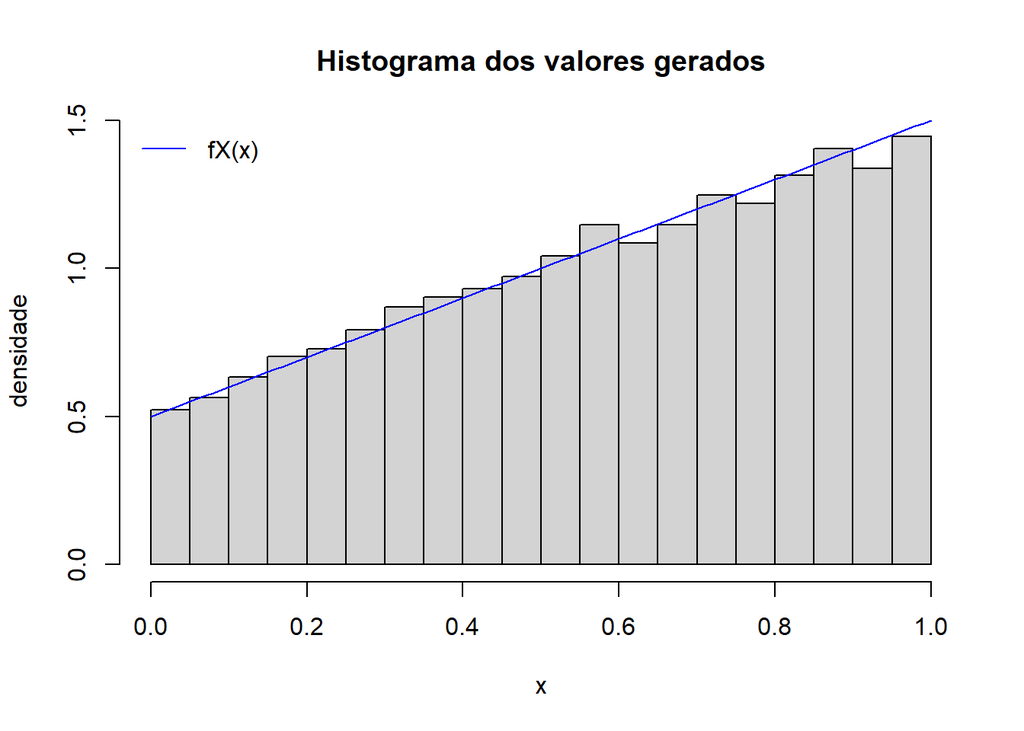

```r
fx_2 <- function(x) ((2*x)+1)/2

x_2 <- gerador_questao_2()
hist(x_2, freq = F, main = "Histograma dos valores gerados",
     xlab = "x", ylab = "densidade")
curve(fx_2(x), from = 0, to = 1, col = "blue", add = T)

legend("topleft", legend = "fX(x)", col = "blue", lty = 1, bty = "n")
```

Logo, conseguimos ver que o gerador está gerando de acordo com a densidade de X.

# Questão 3

Uma vez que a função de densidade da variável aleatória é:

$$f_X(x) = e^{-2|x|}$$

Temos uma semelhança com a densidade de uma exponencial com $\lambda = 2$:

$$f_Y(y) = 2e^{-2y},\ y>=0$$

Com a diferença que a exponencial aceita apenas valores de $y>=0$, e a densidade é multiplicada por dois. No entanto, analisando a $f_X(x)$ percebemos que é uma densidade simétrica onde:

$$f_X(a) = f_X(-a),\ para\ qualquer\ a\ uma\ vez\ que\ abs(a)\ = abs(-a)$$
,

Além disso, temos:

$$f_Y(y) = f_X(a) + f_X(-a)$$

Vamos verficar essa relação graficamente.

```r
fx_3 <- function(x) exp(-2*abs(x))
```

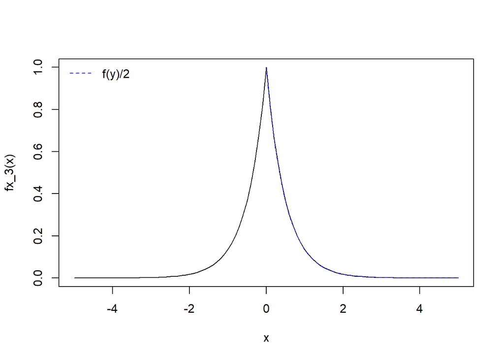

```r
curve(fx_3(x), from = -5, to = 5)
curve(dexp(x, 2)/2, add = T, col = "blue", from = 0, to = 5, lty = 2)
legend("topleft", legend = "f(y)/2", "f(x)", bty = "n", col = c("blue", "black"), lty = c(2, 1))
```

Pelo gráfico, vemos que $f_X(x)$ para $x>=0$ é igual a densidade de $Exp(2)$ dividida por dois, e como $f_X(x)$ é simétrica temos que tal relação também vale para $x<0$.

Ou seja, podemos tentar utilizar a distribuição $Exp(2)$ para gerar os valores e dividir os sinais desses valores entre positvos e negativos a partir de uma $U(0,1)$, onde garantimos que metade dos valores serão menores que 0, e a outra metade maior que 0, para isso os valores da $Uniforme$ menores que 0,5 serão as posições onde os valores de x serão negativos, caso contrário os valores de x serão positivos. Para realizar esse teste vamos gerar para valores de $N = (100, 500, 1000, 10000)$

```r
 # Definindo os valores de n
N <- c(1E2, 5E2, 1E3, 1E4)
 # Gerando as Uniformes para decidir o sinal
U_sinal <- lapply(N, runif)
 # Gerando as exponenciais dependendo de n
exp <- lapply(N, function(n) rexp(n, 2))
 # calculando as amostras a partie das exponencias e uniformes
x_3 <- lapply(1:length(N), function(i) ifelse(U_sinal[[i]] < 0.5, -exp[[i]], exp[[i]]))
```

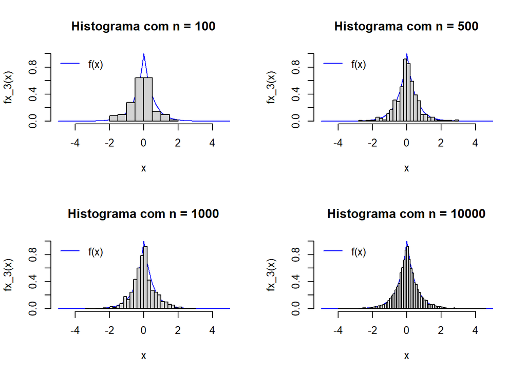

```r
 # Definindo a matriz de gráficos 2x2
par(mfrow = c(2, 2))

 # Plotando um gráfico para cada valor de n
invisible(
  lapply(1:length(N), function(i){
     # Plotando a densidade
    curve(fx_3(x), from = -5, to = 5, main = sprintf("Histograma com n = %s", N[i]), col = "blue", bty = "n")
     # Plotando o histograma
    hist(x_3[[i]], freq = F, breaks = sqrt(N[i]), add = T)
     # Plotando a legenda
    legend("topleft", legend = "f(x)", col = "blue", lty = 1, bty = "n")
    }
  )
)
```

Podemos perceber, a partir dos gráficos, que o histograma das amostras, conforme $n$ aumenta, se aproxima cada vez mais da densidade dada pela função $F_X(x)$.

# Questão 4

Para gerar valores aleatórios a partir do método aceitação/rejeição, vamos definir a função `rejeicao`, que calcula o valor de `M` a partir da função `optimize` aplicada na razão $\frac{f_X(x)}{g_Y(y)}$:

```r
rejeicao <- function(fx, gy, gerador_y, N = 1E4, ...){

  # Parâmetros: fx        - função densidade da distribuição de interesse
  #             gy        - função densidade da distribuição candidata
  #             gerador_y - função geradora de valores da candidata
  #             N         - quantidade de valores, padrão - 10E4
  #             ...       - parâmetros do gerador_y

  # Retorno:  Lista - $x             - valores aceitos
  #                   $y             - y correspondente dos valores aceitos
  #                   $rate          - proporção
  #                   $iteracoes     - número de iterações
  #                   $x_nao_aceitos - valores não aceitos
  #                   $y_nao_aceitos - y correspondente dos valores não aceitos

   # Calculando M
  M <- optimize(f = function(x) fx(x)/gy(x),
                interval = c(0, 1), maximum = T)$objective

   # Iniciando valores faltantes
  faltantes <- N
   # Iniciando vetor x dos aceitos
  x <- c()
   # Iniciando vetor x dos não aceitos
  x_nao_aceito <- c()
   # Iniciando vetor y dos aceitos
  y <- c()
   # Iniciando vetor y dos não aceitos
  y_nao_aceito <- c()
   # Guardando os valores gerados em uma variável
  gerados <- 0

  while(faltantes > 0){
     # Calculando o número de gerados
    gerados <- gerados + faltantes

     # Gerando Y
    Y <- gerador_y(faltantes, ...)
     # Gerando U
    U <- runif(faltantes)

     # Verificando os valores aceitos
    x_i <- ifelse(U <= fx(Y)/(M*gy(Y)), Y, NA)
     # verificando as posições não aceitas
    na_i <- is.na(x_i)
     # salvando os valores aceitos
    x_i_aceito <- x_i[!na_i]
     # calculando y dos valores aceitos
    y_i_aceito <- (U*M*gy(Y))[!na_i]
     # salvando os valores não aceitos
    x_i_nao_aceito <- Y[na_i]
     # calculando y dos valores não aceitos
    y_i_nao_aceito <- (U*M*gy(Y))[na_i]

     # Calculando faltantes
    faltantes <- sum(na_i)
     # juntando pares ordenados dos aceitos
    x <- c(x, x_i_aceito)
    y <- c(y, y_i_aceito)
     # juntando pares ordenados dos não aceitos
    x_nao_aceito <- c(x_nao_aceito, x_i_nao_aceito)
    y_nao_aceito <- c(y_nao_aceito, y_i_nao_aceito)
  }
   # Retornando uma lista com os resultados
  return(list(x = x, y = y, rate = N/gerados, iteracoes = gerados,
              x_nao_aceitos = x_nao_aceito, y_nao_aceitos = y_nao_aceito))
}
```

Além disso, vamos definir uma função para plotar um gráfico desses valores aceitos e não aceitos:

```r
plot_aceitos <- function(x, fx, cor_aceito = "blue", cor_nao_aceito = "red", ...){

  # Parâmetros: x              - lista gerada com valores aceitos e não aceitos
  #             fx             - função densidade da distribuição de interesse
  #             cor_aceito     - cor dos pontos aceitos, padrão - "blue"
  #             cor_nao_aceito - cor dos pontos não aceitos, padrão - "red"
  #             ...            - parâmetros para função plot

  # Retorno:  Gráfico



   # Plotando aceitos
  plot(x$x, x$y, col = cor_aceito, bty = "L", xlab = "x", ylab = "densidade", ...)
   # Plotando não aceitos
  points(x$x_nao_aceitos, x$y_nao_aceitos, col = cor_nao_aceito)
   # Plotando curva de densidade
  curve(fx, col = cor_aceito, add = T)
   # Plotando proporção
  mtext(sprintf("Proporção de aceitos: %.02f%%", x$rate*100),
        line = 1, adj = 0)
}
```

Com isso, vamos considerar $f_X(x) = 30(x^2 - 2x^3 + x^4)$:

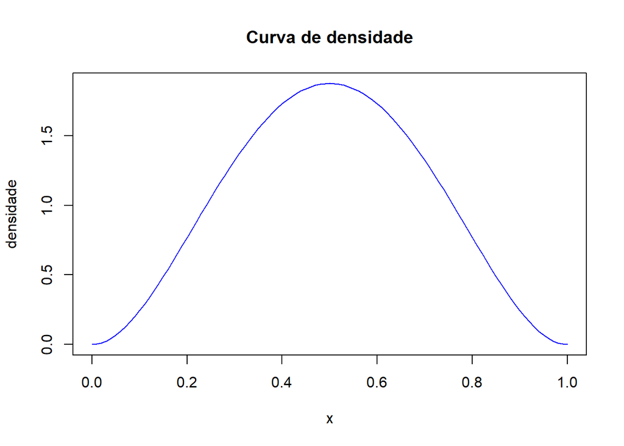

```r
fx_4 <- function(x) 30*((x**2) - (2*(x**3)) + (x**4))
curve(fx_4(x), from = 0, to = 1, col = "blue",
      main = "Curva de densidade", xlab = "x", ylab = "densidade")
```

Dessa forma vamos aplicar a função utilizando a candidata como uma uniforme e vamos observar o resultado:

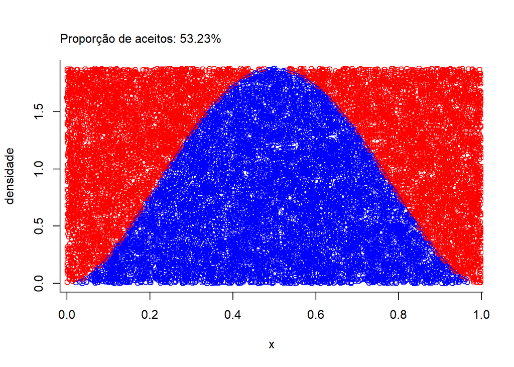

```r
gy_4 <- dunif
x_4 <- rejeicao(fx_4, gy_4, runif)
plot_aceitos(x_4, fx_4)
```

Pela Uniforme, tivemos que $53,23$% dos pontos foram aceitos. Vamos tentar utilizar uma $Beta$ a fim de tentar melhorar essa proporção, primeiramente vamos utilizar uma $Beta(2,2)$:

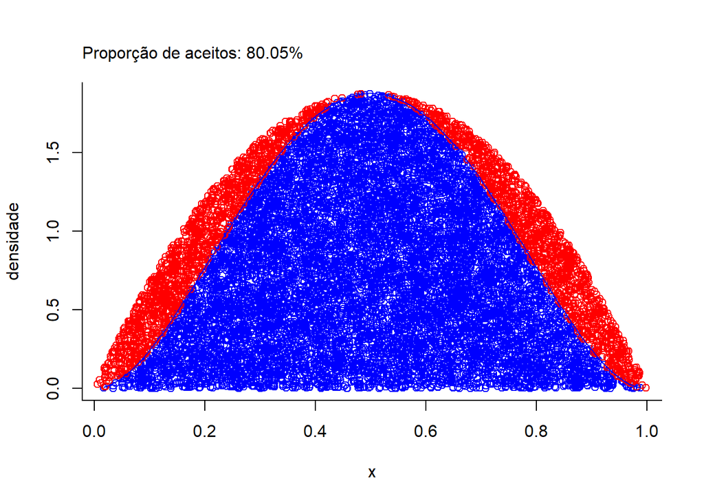

```r
gy_4_beta_2 <- function(x) dbeta(x, 2, 2)
x_4_beta_2 <- rejeicao(fx_4, gy_4_beta_2, rbeta, shape1 = 2, shape2 = 2)
plot_aceitos(x_4_beta_2, fx_4)
```

A proporção dos aceitos subiu para $80,05$%, vamos tentar uma $Beta(3, 3)$ a fim de melhorar ainda mais a proporção:

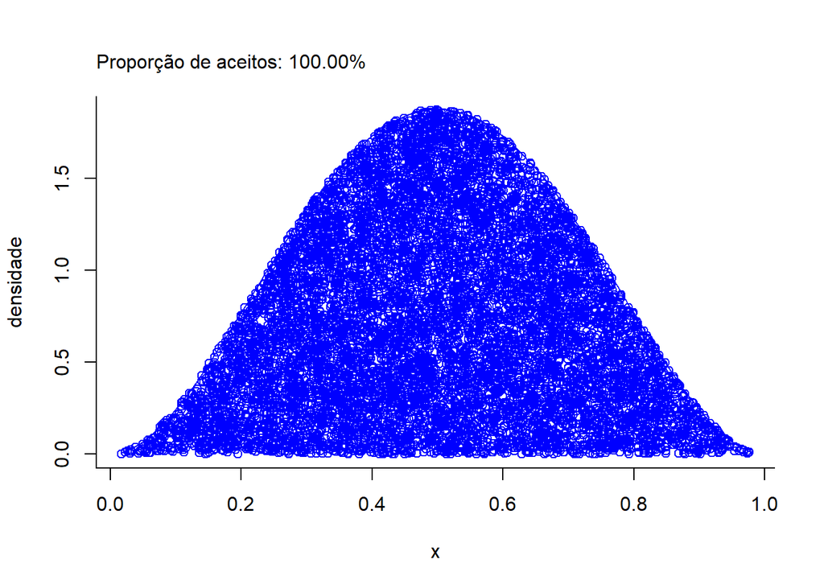

```r
gy_4_beta_3 <- function(x) dbeta(x, 3, 3)
x_4_beta_3 <- rejeicao(fx_4, gy_4_beta_3, rbeta, shape1 = 3, shape2 = 3)
plot_aceitos(x_4_beta_3, fx_4)
```

utilizando a $Beta(3, 3)$ vemos que $100$% dos pontos foram aceitos, ou seja, essa distribuicão segue uma $Beta(3, 3)$.

# Questão 5

Considerando $U$ ~ $Unif(0,1)$, e $X = ln(\frac{U}{1-U})$, podemos definir a função de distribuição de $X$ como:

$$F_X(x) = P(X <= x)$$

Como $X = ln(\frac{U}{1-U})$, temos:

$$F_X(x) = P(ln(\frac{U}{1-U}) <= x)$$
Aplicando a função exponencial em ambos os lados da igualdade, temos:

$$F_X(x) = P(e^{ln(\frac{U}{1-U})} <= e^x)$$
Como $e^{ln(x)} = x$, temos:

$$F_X(x) = P(\frac{U}{1-U} <= e^x)$$

Elevando ambos os lados em $-1$, mudando o sinal da inequação:

$$F_X(x) = P(\frac{1-U}{U} >= e^{-x})$$

Separando a fração $\frac{1-U}{U}$ em dois elementos:

$$F_X(x) = P(\frac{1}{U} - \frac{U}{U} >= e^{-x})$$

Como consideramos $U$ apenas uma variável aletória, temos que $\frac{U}{U}=1$, logo:

$$F_X(x) = P(\frac{1}{U} - 1 >= e^{-x})$$

Ou seja, somando 1 aos dois lados da inequação:

$$F_X(x) = P(\frac{1}{U} >= 1 + e^{-x})$$

Mais uma vez, elevando ambos os lados em $-1$, mudando o sinal da inequação:

$$F_X(x) = P(U <= [{1 + e^{-x}}]^{-1})$$

Pela definição da função de distribuição:

$$F_X(x) = F_U([{1 + e^{-x}}]^{-1})$$

Como $U$ ~ $Unif(0,1)$, $F_U(u) = u$, logo:

$$F_x(x) = [{1 + e^{-x}}]^{-1}$$

Notamos que $F_x(x)$ é equivalente a função de distribuição $Logística(0,1)$, ou seja, $X$ ~ $Logística(0,1)$.

Vamos observar tal relação graficamente:

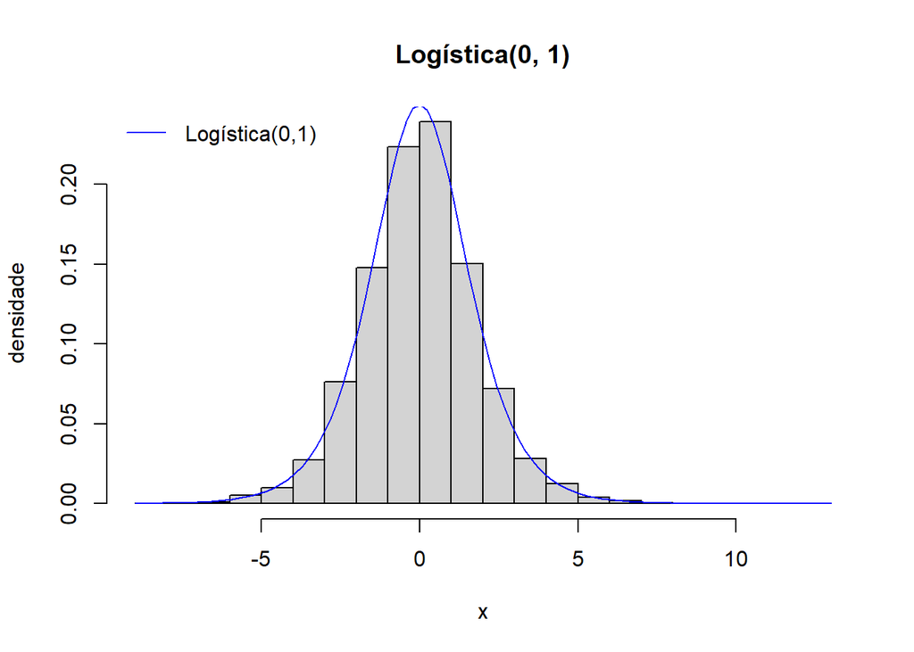

```r
 # Gerando U(0,1)
U <- runif(1E4)
 # Aplicando a transformação
x_5 <- log(U/(1-U))
  # Plotando o histograma
hist(x_5, freq = F, main = "Logística(0, 1)", xlab = "x", ylab = "densidade")
 # Plotando a curva da densidade
curve(dlogis(x, 0, 1), add = T, col = "blue")
 # Plotando a legenda
legend("topleft", legend = "Logística(0,1)", bty = "n", col = "blue", lty = 1)
```

Agora, vamos encontrar a relação de $U$ com a distribuição $Logística(\mu,\beta)$. Para isso vamos considerar $Y$ ~ $Logística(\mu,\beta)$, sabemos que:

$$F_Y(y) =[{1 + e^{-\frac{(y-\mu)}{\beta}}}]^{-1}$$

Além disso, considerando $F_U(u) = u$, podemos estabeler a seguinte igualdade:

$$F_U([{1 + e^{-\frac{(y-\mu)}{\beta}}}]^{-1}) = [{1 + e^{-\frac{(y-\mu)}{\beta}}}]^{-1}$$

Logo:

$$F_Y(y) = F_U([{1 + e^{-\frac{(y-\mu)}{\beta}}}]^{-1})$$

Pela definição de $F_U(u) = P(U <= u)$, temos:

$$F_Y(y) = P(U <= [{1 + e^{-\frac{(y-\mu)}{\beta}}}]^{-1})$$

Elevando ambos os lados em $-1$, mudando o sinal da inequação:

$$F_Y(y) = P(\frac{1}{U} >= {1 + e^{-\frac{(y-\mu)}{\beta}}})$$

Subtraindo 1 em ambos os lados da inequação:

$$F_Y(y) = P(\frac{1}{U} - 1 >= e^{-\frac{(y-\mu)}{\beta}})$$

Resolvendo $\frac{1}{U} - 1$:

$$F_Y(y) = P(\frac{1}{U} - \frac{U}{U} >= e^{-\frac{(y-\mu)}{\beta}})$$

Ou seja:

$$F_Y(y) = P(\frac{1-U}{U} >= e^{-\frac{(y-\mu)}{\beta}})$$

Elevando ambos os lados em $-1$, mudando o sinal da inequação:

$$F_Y(y) = P(\frac{U}{1-U} <= e^{\frac{(y-\mu)}{\beta}})$$

Aplicando a função $ln$ em ambos os lados:

$$F_Y(y) = P(ln(\frac{U}{1-U}) <= ln(e^{\frac{(y-\mu)}{\beta}}))$$

Como $ln(e^x) = x$, temos:

$$F_Y(y) = P(ln(\frac{U}{1-U}) <= \frac{(y-\mu)}{\beta})$$

Multiplicando ambos os lados por $\beta$, e, posteriormente, somando $\mu$, temos:

$$F_Y(y) = P(\beta*ln(\frac{U}{1-U}) + \mu <= y)$$

ou seja, como:

$$F_Y(Y) = P(Y <= y)$$

Concluímos:

$$Y = \beta*ln(\frac{U}{1-U}) + \mu$$

Onde, $Y$ ~ $Logística(\mu,\beta)$

A fim de visualizar graficamente esses resultados vamos gerar uma amostra a partir dessa transformação e observar:

```r
 # Definindo a função para gerar uma Logistica(mu, beta)
gera_logistica <- function(N, mu = 0, beta = 1){
  U <- runif(N)
  (beta*log(U/(1-U)))+mu
}
```

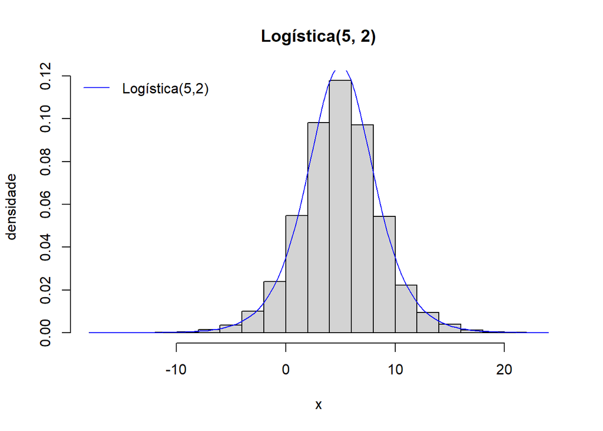

```r
 # Definindo valor de mu
mu <- 5
 # Definindo valor de beta
beta <- 2
 # Gerando a amostra
x_log_5_2 <- gera_logistica(1E4, mu, beta)
 # Plotando o histograma
hist(x_log_5_2, freq = F, main = "Logística(5, 2)", xlab = "x", ylab = "densidade")
 # Plotando a curva da densidade
curve(dlogis(x, mu, beta), add = T, col = "blue")
 # Plotando a legenda
legend("topleft", legend = "Logística(5,2)", bty = "n", col = "blue", lty = 1)
```

Dessa forma, conseguimos ver essa relação empiricamente onde a curva da densidade da $Logística$ se adequa ao histograma dos valores gerados.

# Questão 6

A fim de analisar tal algoritmo, vamos implementá-lo:

```r
gera_U_alpha <- function(alpha, N){
  # alpha - parâmetro da beta
  # N - tamanho da amostra

   # Iniciando o vetor x
  x <- c()
   # verificar se alpha não estiver entre 0 e 1
  stopifnot(alpha < 1 & alpha > 0)
   # calculando o valor de valores faltantes
  faltantes <- N

   # gerando um loop enquanto existir valores faltantes
  while(faltantes > 0){
     # Gerando U(0,1)
    U <- runif(faltantes)
     # Filtrando U <= alpha
    x_i <- ifelse(U <= alpha, U, NA)
     # definindo as posições que retornaram NA
    na_i <- is.na(x_i)
     # calculando o valor de valores faltantes
    faltantes <- sum(na_i)
     # concatenando os valores aceitos
    x <- c(x, x_i[!na_i])
  }

   # Retornando x
  x
}
```

Vamos observar um exemplo quando $\alpha = 0.9$:

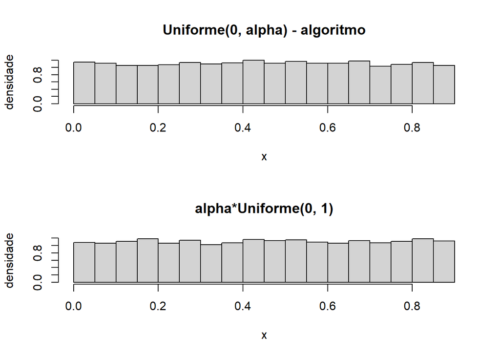

```r
par(mfrow = c(2, 1))
 # Definindo alpha
alpha <- 0.9
 # Definindo tamanho da amostra
N <- 1E4
 # Gerando a amostra pelo algoritmo
x_6_alpha_0.9 <- gera_U_alpha(alpha, N)
 # Gerando o histograma
hist(x_6_alpha_0.9, freq = F, main = "Uniforme(0, alpha) - algoritmo", xlab = "x", ylab = "densidade")

 # Gerando a uniforme
U <- runif(N)
 # gerando o histograma
hist(alpha*U, freq = F, main = "alpha*Uniforme(0, 1)", xlab = "x", ylab = "densidade")
```

Agora para compara ambos os metodos vamos utilizar o pacote `microbenchmark` a fim de verificar os tempos de execução:

```r
library(microbenchmark)
```

Primeiro utilizando $alpha=0.7$ e $N=10^4$:

```r
microbenchmark(gera_U_alpha(0.7, 1E4),
               0.9*runif(1E4))
```

```
## Unit: microseconds
##                      expr   min      lq     mean median      uq    max neval
##  gera_U_alpha(0.7, 10000) 991.9 1055.70 1355.824 1132.6 1442.85 3145.6   100
##        0.9 * runif(10000) 296.7  297.65  355.941  301.0  337.30 3473.0   100
```

Utilizando $alpha=0.8$ e $N=10^4$:

```r
microbenchmark(gera_U_alpha(0.8, 1E4),
               0.8*runif(1E4))
```

```
## Unit: microseconds
##                      expr   min    lq     mean median      uq    max neval
##  gera_U_alpha(0.8, 10000) 812.4 864.8 1027.131 898.00 1001.60 2845.1   100
##        0.8 * runif(10000) 296.6 297.6  319.102 299.85  335.25  456.5   100
```

Utilizando $alpha=0.9$ e $N=10^4$:

```r
microbenchmark(gera_U_alpha(0.9, 1E4),
               0.9*runif(1E4))
```

```
## Unit: microseconds
##                      expr   min     lq    mean median    uq    max neval
##  gera_U_alpha(0.9, 10000) 674.6 708.95 862.491 741.75 824.6 3965.5   100
##        0.9 * runif(10000) 296.6 297.50 322.127 299.55 328.1  593.0   100
```

Utilizando $alpha=0.99$ e $N=10^4$:

```r
microbenchmark(gera_U_alpha(0.99, 1E4),
               0.99*runif(1E4))
```

```
## Unit: microseconds
##                       expr   min     lq    mean median     uq    max neval
##  gera_U_alpha(0.99, 10000) 547.0 581.00 776.366 610.25 753.25 3245.3   100
##        0.99 * runif(10000) 296.7 297.55 330.354 308.60 339.30  610.4   100
```

utilizando $alpha=0.999$ e $N=10^4$:

```r
microbenchmark(gera_U_alpha(0.999, 1E4),
               0.999*runif(1E4))
```

```
## Unit: microseconds
##                        expr   min     lq    mean median      uq    max neval
##  gera_U_alpha(0.999, 10000) 529.8 554.40 826.845 614.75 1001.25 5795.8   100
##        0.999 * runif(10000) 296.5 299.15 332.545 330.10  358.20  483.9   100
```

Logo podemos concluir, que o método de $\alpha*U$ é mais eficiente, no entanto, quanto mais próximo de 1 é o valor de $\alpha$ menor o tempo de execução do algoritmo.

# Questão 7

## Letra a

A fim de gerar uma $Beta(\alpha, \beta)$ a partir de uma uniforme vamos utilizar a função `rejeicao` defininda anteriormente, além disso, vamos testar a geração de uma $beta(2.7,6.3)$:

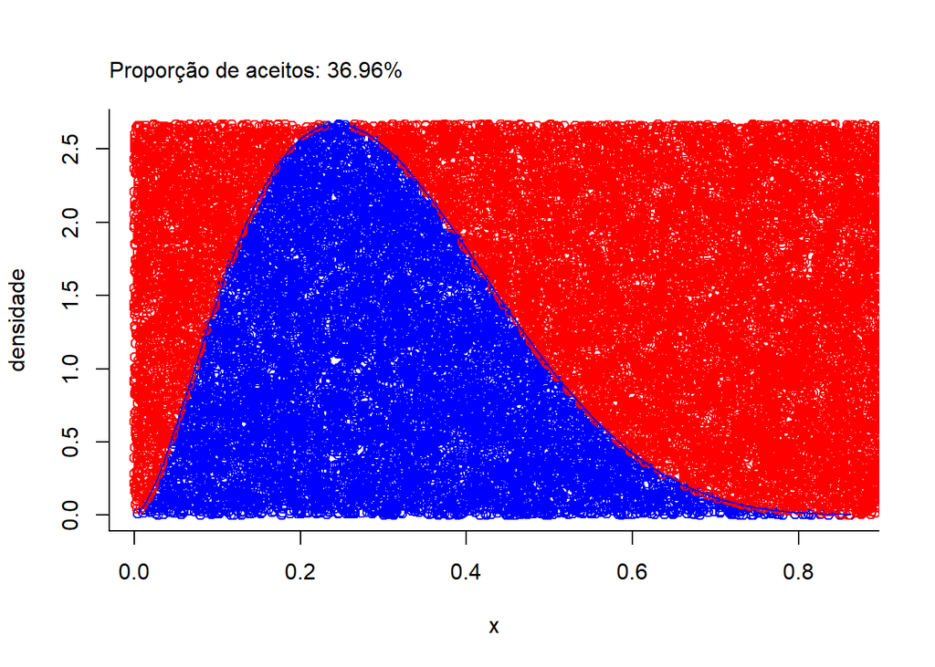

```r
fx_7 <- function(x) dbeta(x, shape1 = 2.7, shape2 = 6.3)
x_7_a <- rejeicao(fx_7, dunif, runif)
plot_aceitos(x_7_a, fx_7)
```

Vemos que utilizando uma uniforme como candidata tivemos $36,96$% de aceitos.

## Letra b

Utilizando o exemplo 2.2, vamos gerar uma $Beta(2.7, 6.3)$ a partir de uma $Beta(2,6)$, além disso, vamos gerar esse $Beta(2,6)$ a partir de exponencias de acordo com a seguinte relação, dado que $X_j$ ~ $Exp(1)$, seja Y:

$$Y = \frac{\sum^{a}_{j=1}X_j}{\sum^{a+b}_{j=1}X_j}$$

Temos que $Y$ ~ $Beta(a, b)$, logo vamos implementar esse algoritmo:

```r
gera_beta_exp <- function(N, alpha, beta){

  #Parâmetros: N     - número de valores
  #            alpha - parâmetro da beta
  #            beta  - parâmetro da beta


   # aplicando lapply para garantir que seja vetorizado
  unlist(lapply(1:N, function(i){
     # gerando a exponencial
    xj <- rexp(alpha+beta)
     # gerando a beta(a,b)
    sum(xj[1:alpha])/sum(xj)
  }
 )
)
}
```

Dessa forma, vamos gerar a $Beta(2.7, 6.3)$ utilizando uma $Beta(2,6)$ como candidata, gerada pela função `gera_beta_exp`.

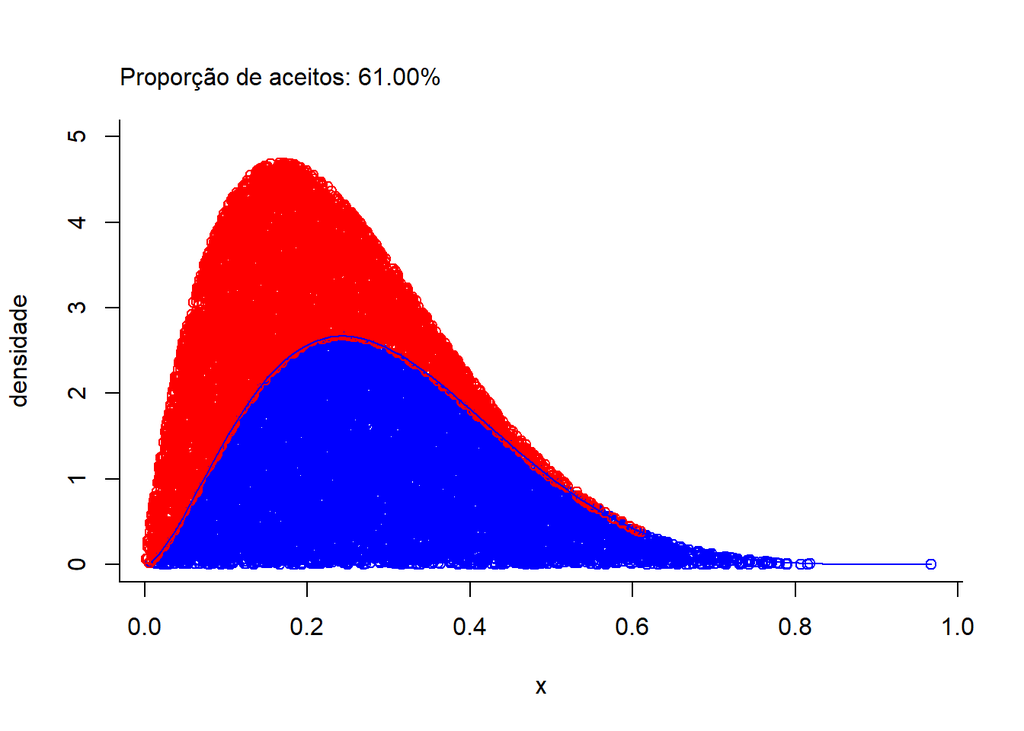

```r
gy_7 <- function(x) dbeta(x, shape1 = 2, shape2 = 6)
x_7_b <- rejeicao(fx_7, gy_7, gera_beta_exp, alpha = 2, beta = 6)
plot_aceitos(x_7_b, fx_7, ylim = c(0,5))
```

Vemos, que utilizando um $Beta(2,6)$ houve uma grande melhora em relação utilizar uma uniforme, onde a proporção subiu para $61$%.

## Letra c

A fim de gerar os valores de uma normal truncada vamos utilizar a função `rtnorm` do pacote `TruncatedNormal`. Com isso, vamos definir os limites como 0 e 1, uma vez que queremos gerar uma beta, logo assume valores entre 0 e 1.

```r
library(TruncatedNormal)
```

Para isso, como a normal depende da media e variância, vamos construir uma função para variar esses parâmetros e analisar qual a melhor opção a fim de gerar uma $Beta(2.7,6.3)$.

```r
gera_beta_7_c <- function(mean, sd, N = 1E4, alpha = 2.7, beta = 6.3){
   rejeicao(function(x) dbeta(x, alpha, beta),
            function(x) dnorm(x, mean, sd),
            function(n) rtnorm(n = n, mu = mean, sd = sd, lb = 0, ub = 1),
            N = N)
}
```

Utilizando $N(0.5, 1)$:

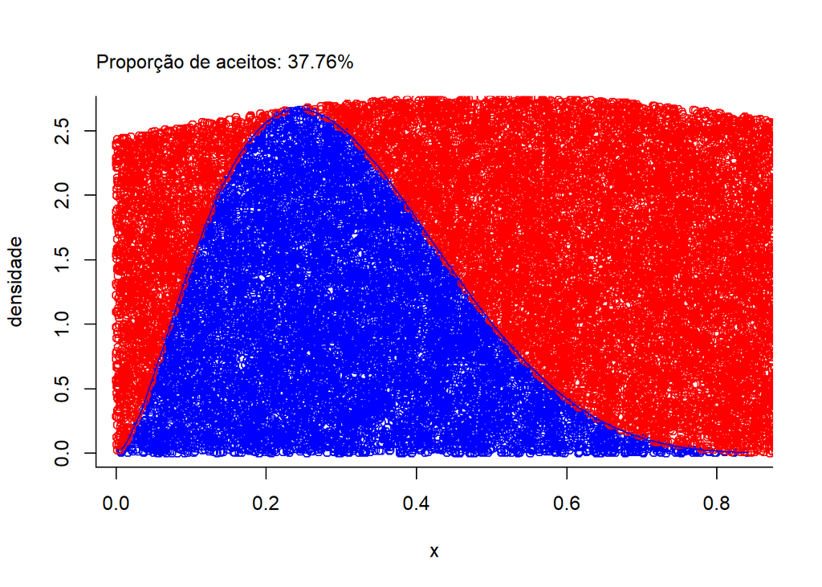

```r
x_beta_7_c_1 <- gera_beta_7_c(0.5, 1)
plot_aceitos(x_beta_7_c_1, fx_7)
```

Acredito que para melhorar podemos diminuir a média, uma vez que existe uma assimetria à direita, e além disso diminuir a variância a fim de concentrar mais os valores, utilizando uma $N(0.25,0.2)$:

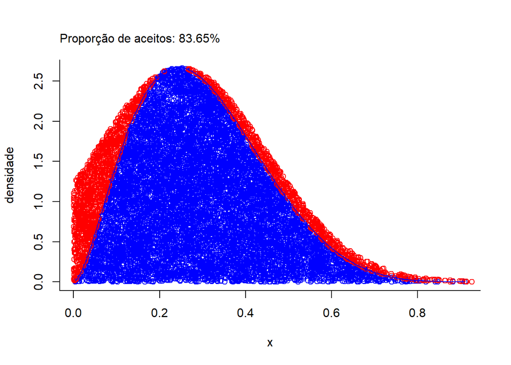

```r
x_beta_7_c_1 <- gera_beta_7_c(0.25, 0.2)
plot_aceitos(x_beta_7_c_1, fx_7)
```

Dessa vez, com uma $N(0.25,0.2)$ truncada entre 0 e 1, vemops que a proporção de aceitos melhorou muito, acima dos $80$%.

# Questão 8

## Letra a

Vamos implemetar uma função a fim de construir um gerador congruencial:

```r
gerador_congruencial <- function(x0, N, a = 17, m = (2**13) - 1, c = 0){
  # Parâmetros:
  #            x0- valor inical
  #            N - número de valores
  #            a - multiplicador
  #            c - incremento
  #            m -modulo
  x <- x0
  for(i in 1:N){
    x[i+1] <- (a*x[i] + c) %% m
  }
  x[2:(N+1)]
}
```

## Letra b

Gerando 500 valores com $a = 17$, $m=2^{13} - 1$ e $c=0$, utilizando $x_0=3$

```r
x_8 <- gerador_congruencial(x0 = 3, N = 500)
```

## Letra c

```r
cor(x_8[1:499], x_8[2:500])
```

```
## [1] 0.08323861
```

Calculando a correlação de $x_i$ com $x_{i+1}$ vemos que existe uma correlação baixa de, aproximadamente, 8%.

## Letra d

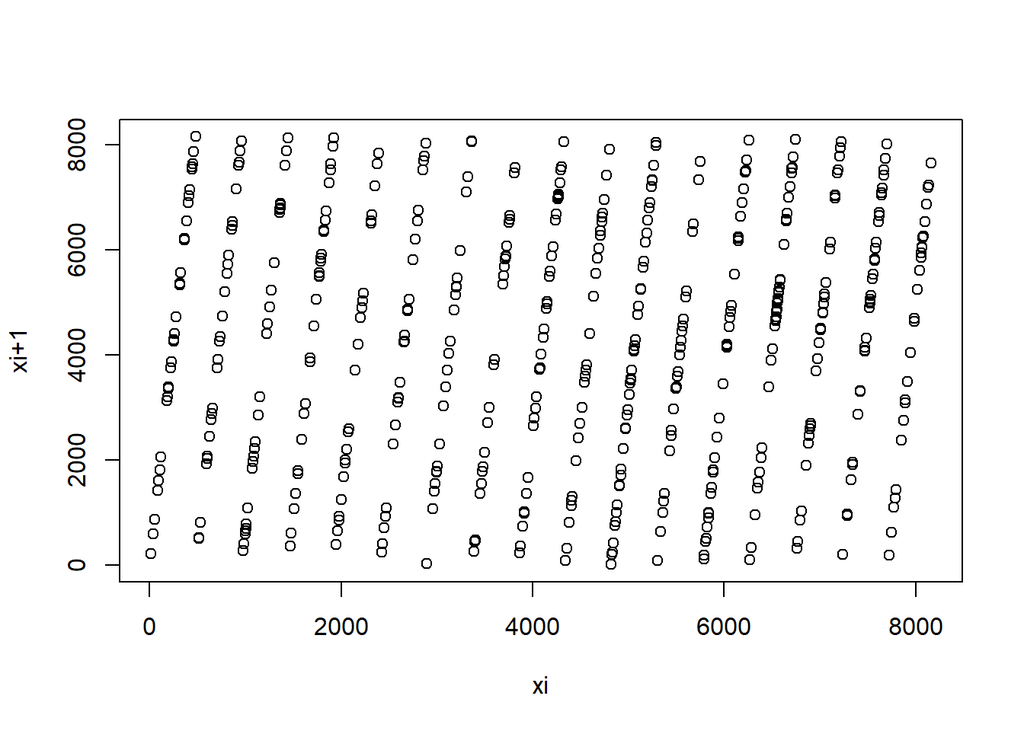

```r
plot(x_8[1:499], x_8[2:500], xlab = "xi", ylab = "xi+1")
```

A partir do gráfico, vemos que os pontos estão situados em 17 linhas, ou seja, mesmo valor do multiplicador $a$.

## Letra e

Modificando $a=85$ dessa vez:

```r
x_8_e <- gerador_congruencial(x0 = 3, N = 500, a = 85)
cor(x_8_e[1:499], x_8_e[2:500])
```

```
## [1] 0.01298798
```

Podemos ver que a correlação de $x_i$ com $x_{i+1}$ diminuiu bastante quando $a$ aumentou, dessa vez foi aproximadamente 1%.

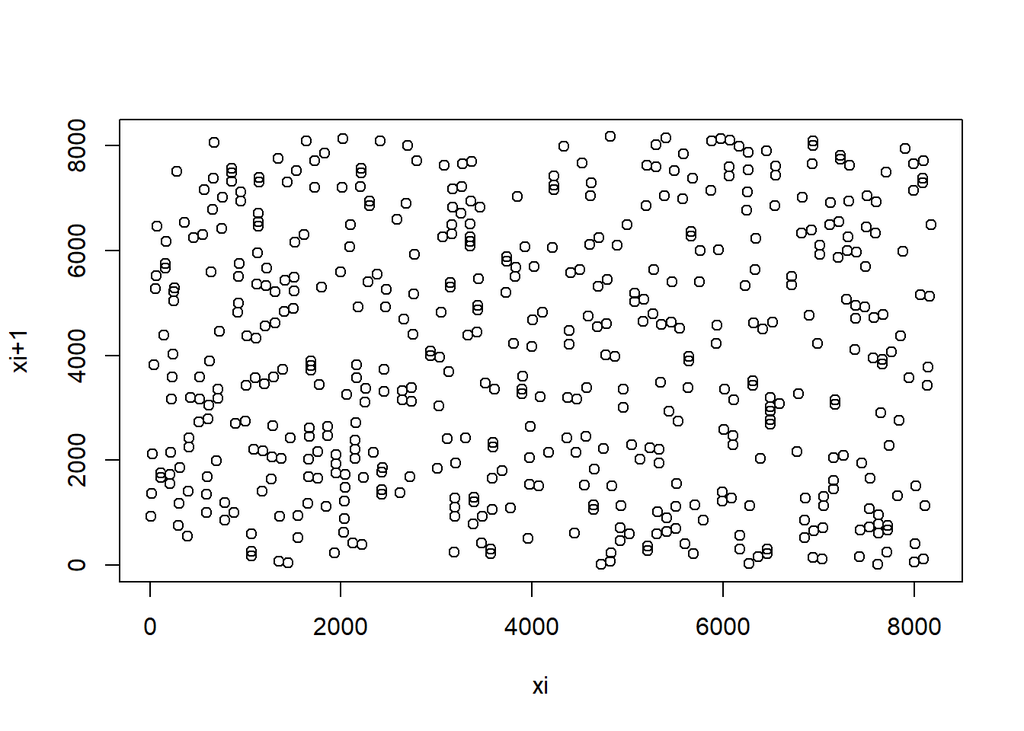

```r
plot(x_8_e[1:499], x_8_e[2:500], xlab = "xi", ylab = "xi+1")
```

Pelo gráfico não conseguimos mais ver o padrão visto quando $a$ era 17, dessa vez os pontos estão masi distribídos.

## Letra f

Considerando $a=17$, temos:

```r
cor(x_8[1:498], x_8[3:500])
```

```
## [1] -0.008076801
```

Observando a correlação de $x_i$ com $x_{i+2}$ vemos que existe uma correlação negativa, porém muito pequena.

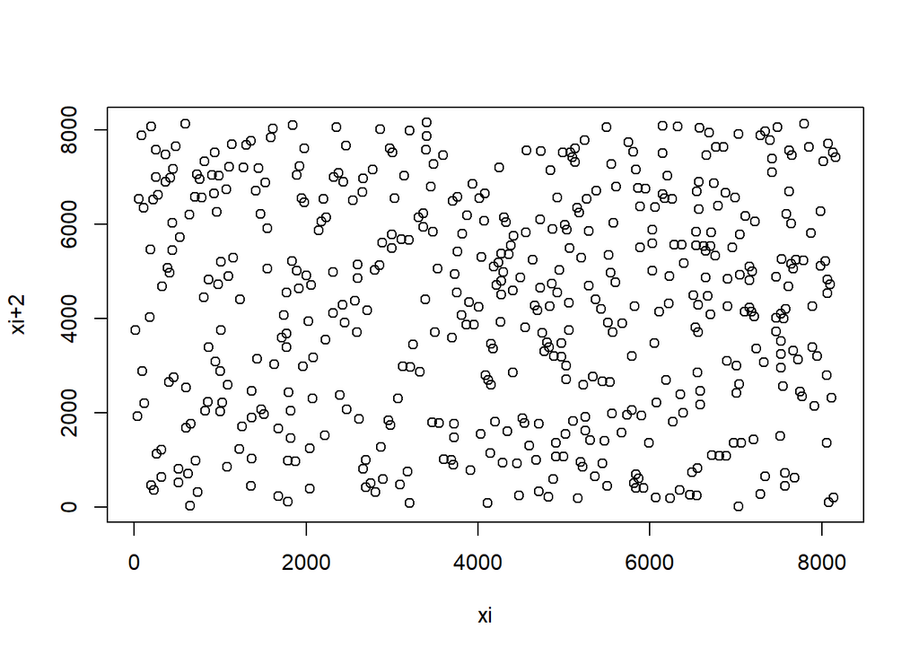

```r
plot(x_8[1:498], x_8[3:500], xlab = "xi", ylab = "xi+2")
```

Nota-se, pelo gráfico, que não existe mais um padrão da relação dos pontos entre $x_i$ com $x_{i+2}$ como era visto entre $x_i$ com $x_{i+1}$.

Agora, considerando $a=85$:

```r
cor(x_8_e[1:498], x_8_e[3:500])
```

```
## [1] -0.02321967
```

Observando a correlação de $x_i$ com $x_{i+2}$ vemos que existe uma correlação negativa, porém pequena, no entanto essa correlação foi mais forte que $a=17$.

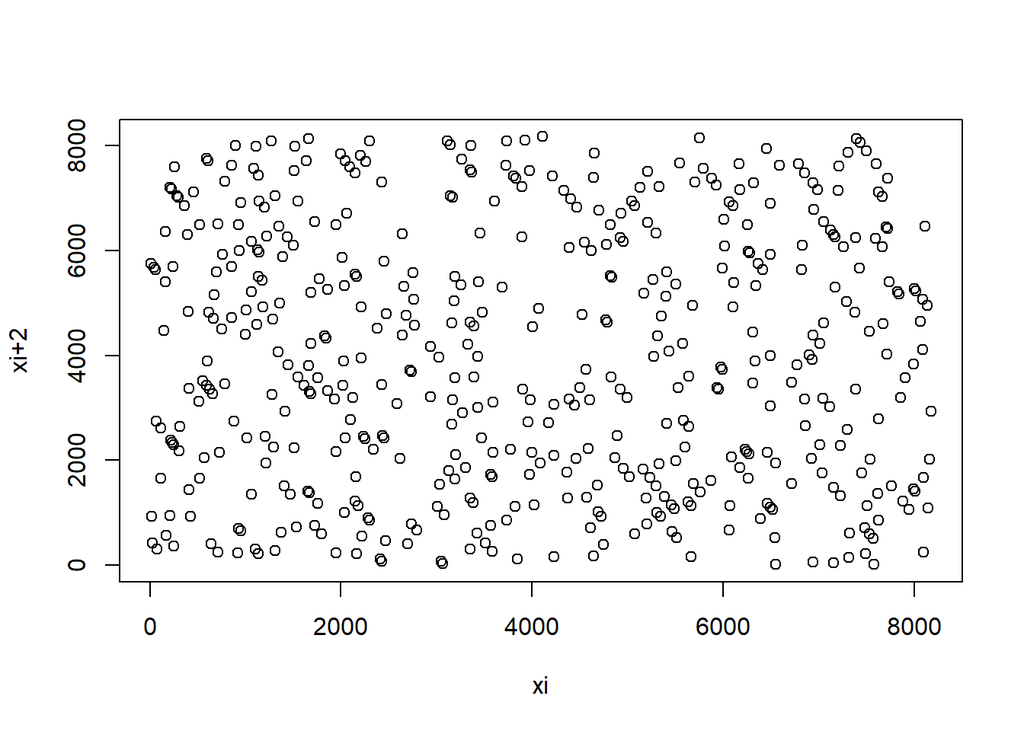

```r
plot(x_8_e[1:498], x_8_e[3:500], xlab = "xi", ylab = "xi+2")
```

Observando o gráfico, aparenta que os pontos não estão distribídos de forma totalmente aletória, parece haver uma relação negativa, porém pequena.

# Letra g

Concluímos, que para um valor de $a$ pequeno os valores gerados apresentam certa correlação, principalmente entre o valor posterior, indicando que não é a melhor forma de gerar valores aleatórios, uma vez que o valor $x_{i+1}$ está correlacionado com o valor de $x_i$, no entanto, esse problema pode ser minimizado com um valor maior de $a$.